# HW1

박찬영

2024-09-27

```r
# load required packages
library(tidyverse)
library(palmerpenguins)
library(nycflights13)
```

### Textbook 1.2.5 problem 8

Recreate the following visualization. What aesthetic should bill_depth_mm be mapped to? And should it be mapped at the global level or at the geom level?

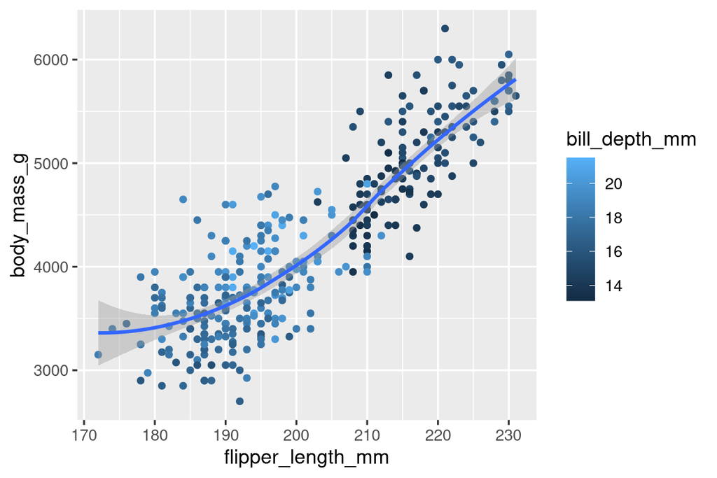

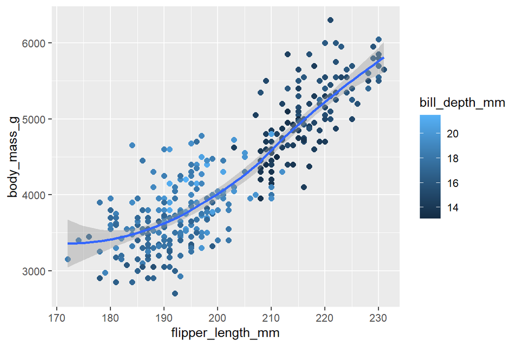

```r
#recreate visulalization
ggplot(penguins,aes(flipper_length_mm,body_mass_g)) +
  geom_point(aes(color=bill_depth_mm),size=2) +
  geom_smooth()
```

```r
#bill_depth_mm 컬럼은 color로 aes에서 mapping 되었다
#bill_depth_mm 컬럼은 geom수준에서 매핑되어야합니다
#global에서 매핑될경우 geom_smooth에도 영향을 줍니다
#bill_depth_mm은 수치형 변수라서 geom_smooth에서 작동을 못합니다
```

### Textbook 1.5.5 problem 6

Why does the following yield two separate legends? How would you fix it to combine the two legends?

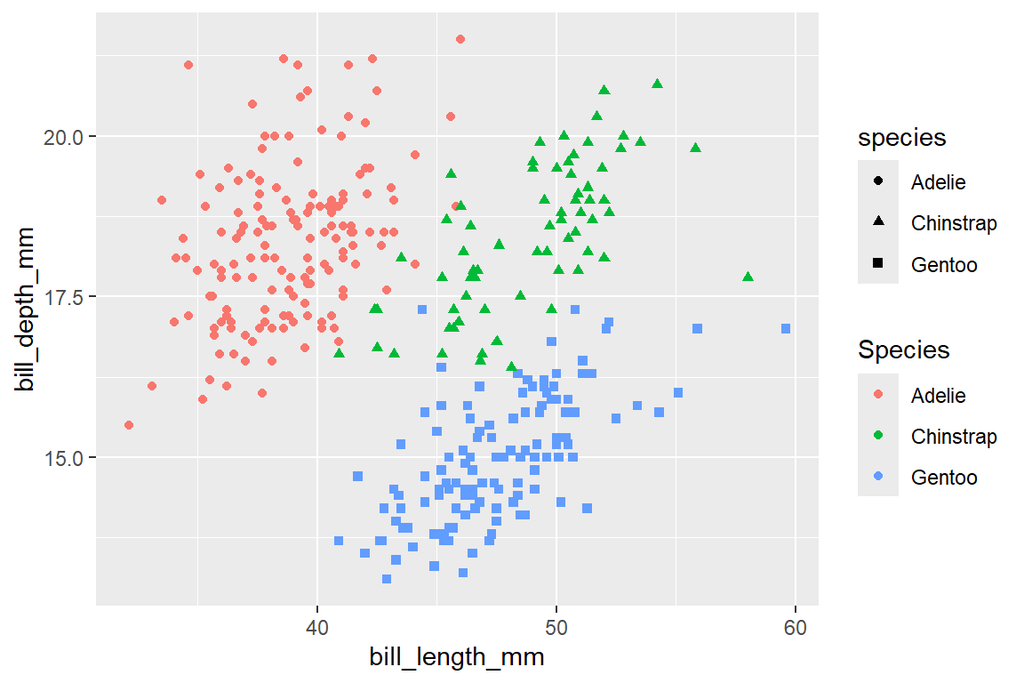

```r
ggplot(
  data = penguins,
  mapping = aes(
    x = bill_length_mm, y = bill_depth_mm,
    color = species, shape = species
  )
) +
  geom_point() +
  labs(color = "Species")
```

주어진 코드에서 Species로 labs 이름을 지정하여서 species 컬럼과 분리되어서 범례가 보인다. 단순히 labs()를 없애거나 shape=“Species”를 추가하면 된다.

다음은 고친 코드와 결과이다

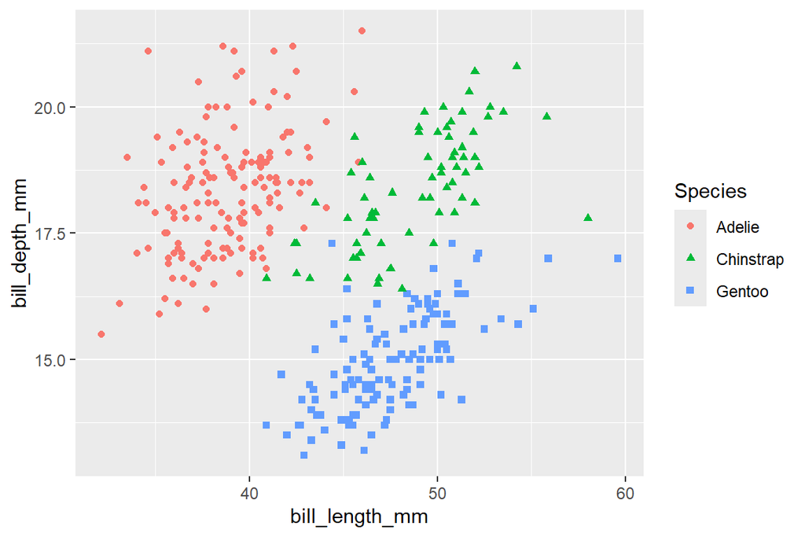

```r
ggplot(
  data = penguins,
  mapping = aes(
    x = bill_length_mm, y = bill_depth_mm,
    color = species, shape = species
  )
) +
  geom_point() +
  labs(color = "Species",shape="Species") #labs는 없어도 범례가 하나로 보인다
```

### Textbook 9.4.1 problem 7

Recreate the following plot using facet_wrap() instead of facet_grid(). How do the positions of the facet labels change?

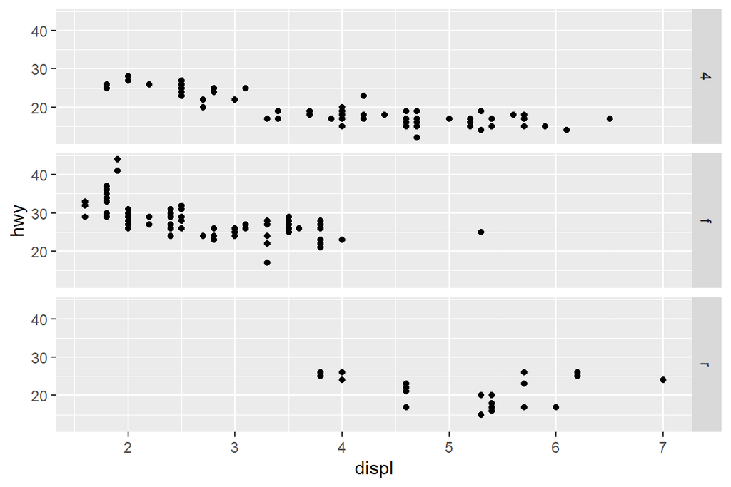

```r
ggplot(mpg) +
  geom_point(aes(x = displ, y = hwy)) +
  facet_grid(drv ~ .)
```

다음은 고친 코드이다

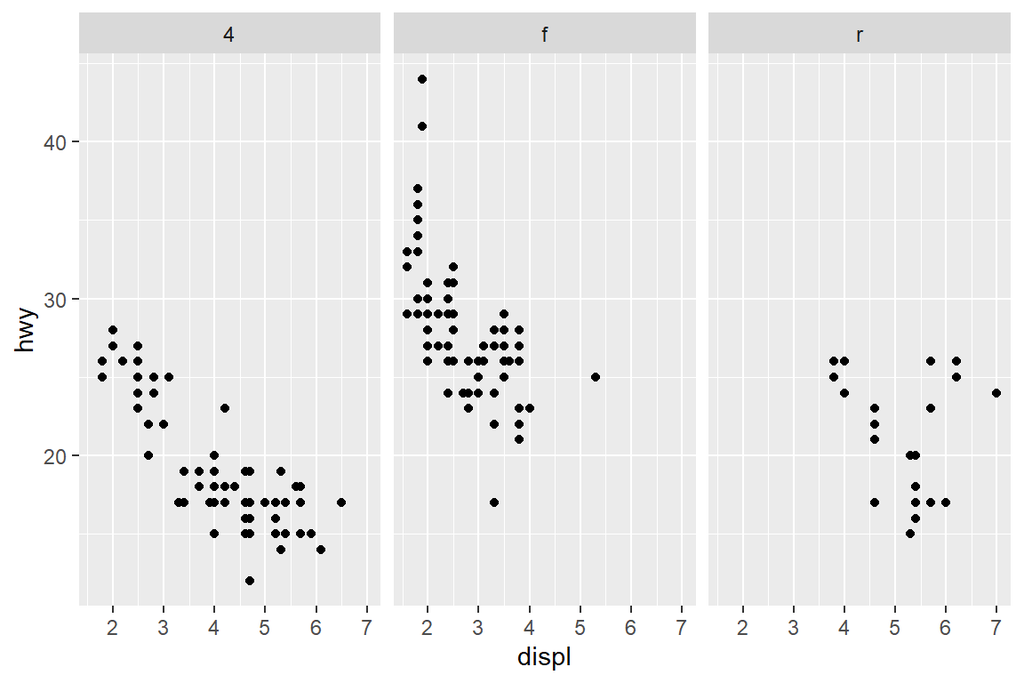

```r
ggplot(mpg) +
  geom_point(aes(x = displ, y = hwy)) +
  facet_wrap(~drv)
```

```r
#facet label이 우측에서 위로 간것을 볼 수 있다
```

### Textbook 11.2.1 problem 2

Recreate the following plot using the fuel economy data. Note that both the colors and shapes of points vary by type of drive train.

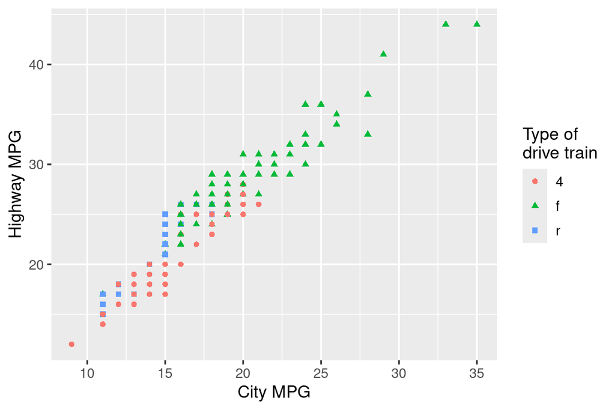

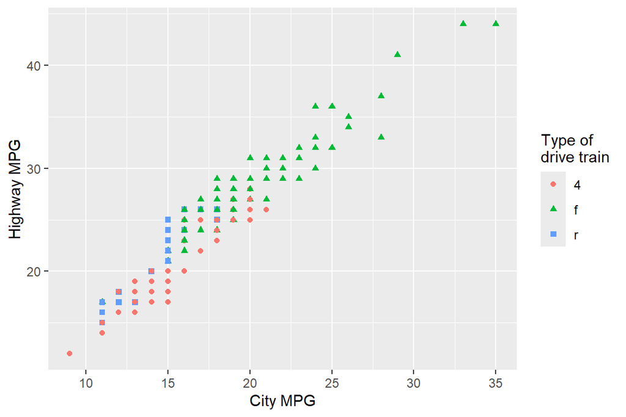

```r
ggplot(mpg,aes(cty,hwy)) +
  geom_point(aes(color=drv,shape=drv)) +
  labs(
    x="City MPG",
    y="Highway MPG",
    color="Type of\ndrive train",
    shape="Type of\ndrive train"
    )
```

### Textbook 3.2.5 problem 3

Sort flights to find the fastest flights. (Hint: Try including a math calculation inside of your function.)

```r
flights %>%
  arrange(desc(distance/air_time))
```

```
## # A tibble: 336,776 × 19
##     year month   day dep_time sched_dep_time dep_delay arr_time sched_arr_time
##    <int> <int> <int>    <int>          <int>     <dbl>    <int>          <int>
##  1  2013     5    25     1709           1700         9     1923           1937
##  2  2013     7     2     1558           1513        45     1745           1719
##  3  2013     5    13     2040           2025        15     2225           2226
##  4  2013     3    23     1914           1910         4     2045           2043
##  5  2013     1    12     1559           1600        -1     1849           1917
##  6  2013    11    17      650            655        -5     1059           1150
##  7  2013     2    21     2355           2358        -3      412            438
##  8  2013    11    17      759            800        -1     1212           1255
##  9  2013    11    16     2003           1925        38       17             36
## 10  2013    11    16     2349           2359       -10      402            440
## # ℹ 336,766 more rows
## # ℹ 11 more variables: arr_delay <dbl>, carrier <chr>, flight <int>,
## #   tailnum <chr>, origin <chr>, dest <chr>, air_time <dbl>, distance <dbl>,
## #   hour <dbl>, minute <dbl>, time_hour <dttm>
```

### Textbook 3.2.5 problem 4

Was there a flight on every day of 2013?

```r
flights %>%
  distinct(year,month,day) %>%
  nrow()
```

```
## [1] 365
```

```r
#2013년은 윤년이 아니라 365일이므로 모든 날짜에 비행이 있었다
```

### Textbook 3.5.7 problem 2

Find the flights that are most delayed upon departure from each destination.

```r
flights %>%
  group_by(dest) %>%
  arrange(desc(dep_delay)) %>%
  filter(c(TRUE,rep(FALSE,n()-1)))
```

```
## # A tibble: 105 × 19
## # Groups:   dest [105]
##     year month   day dep_time sched_dep_time dep_delay arr_time sched_arr_time
##    <int> <int> <int>    <int>          <int>     <dbl>    <int>          <int>
##  1  2013     1     9      641            900      1301     1242           1530
##  2  2013     6    15     1432           1935      1137     1607           2120
##  3  2013     1    10     1121           1635      1126     1239           1810
##  4  2013     9    20     1139           1845      1014     1457           2210
##  5  2013     7    22      845           1600      1005     1044           1815
##  6  2013     4    10     1100           1900       960     1342           2211
##  7  2013     3    17     2321            810       911      135           1020
##  8  2013     6    27      959           1900       899     1236           2226
##  9  2013     7    22     2257            759       898      121           1026
## 10  2013    12     5      756           1700       896     1058           2020
## # ℹ 95 more rows
## # ℹ 11 more variables: arr_delay <dbl>, carrier <chr>, flight <int>,
## #   tailnum <chr>, origin <chr>, dest <chr>, air_time <dbl>, distance <dbl>,
## #   hour <dbl>, minute <dbl>, time_hour <dttm>
```

```r
#각 목적지별로 가장 지연된 비행기편만 모아져있다
#max함수에 NA가 들어가면 문제가 생겨서 정렬 후 첫번째 행들만 모으는 코드를 짰다
#summarise(most_delay=first(dep_delay))를 쓸 수도 있지만 이러면 각 비행편의 정보가 사라지고
#filter(dep_delay==first(dep_delay))로 하면 NA==NA의 문제가 발생하여 이렇게 코드를 짰다
```

### Textbook 12.5.4 problem 3

se if_else() to compute the absolute value of a numeric vector called x.

```r
ab <- function(x) {
  return(if_else(x>=0,x,-x))
}
x <- c(15, -30, 0, -20)
ab(x)
```

```
## [1] 15 30  0 20
```

### Textbook 13.3.1 problem 2

Expand the following calls to count() to instead use group_by(), summarize(), and arrange():

1. flights |> count(dest, sort = TRUE)
2. flights |> count(tailnum, wt = distance)

```r
#1
flights %>%
  group_by(dest) %>%
  summarise(count=n()) %>%
  arrange(desc(count))
```

```
## # A tibble: 105 × 2
##    dest  count
##    <chr> <int>
##  1 ORD   17283
##  2 ATL   17215
##  3 LAX   16174
##  4 BOS   15508
##  5 MCO   14082
##  6 CLT   14064
##  7 SFO   13331
##  8 FLL   12055
##  9 MIA   11728
## 10 DCA    9705
## # ℹ 95 more rows
```

```r
#2
flights %>%
  group_by(tailnum) %>%
  summarise(count=sum(distance))
```

```
## # A tibble: 4,044 × 2
##    tailnum  count
##    <chr>    <dbl>
##  1 D942DN    3418
##  2 N0EGMQ  250866
##  3 N10156  115966
##  4 N102UW   25722
##  5 N103US   24619
##  6 N104UW   25157
##  7 N10575  150194
##  8 N105UW   23618
##  9 N107US   21677
## 10 N108UW   32070
## # ℹ 4,034 more rows
```

### Textbook 13.5.4 problem 5

For each destination, compute the total minutes of delay. For each flight, compute the proportion of the total delay for its destination.

```r
flights %>%
  group_by(dest) %>%
  mutate(total_delay=sum(arr_delay,na.rm=TRUE)) %>%
  mutate(prop_delay=arr_delay/total_delay) %>%
  select(prop_delay, total_delay, colnames(flights))
```

```
## # A tibble: 336,776 × 21
## # Groups:   dest [105]
##    prop_delay total_delay  year month   day dep_time sched_dep_time dep_delay
##         <dbl>       <dbl> <int> <int> <int>    <int>          <int>     <dbl>
##  1  0.000366        30046  2013     1     1      517            515         2
##  2  0.000666        30046  2013     1     1      533            529         4
##  3  0.00952          3467  2013     1     1      542            540         2
##  4 -0.00246          7322  2013     1     1      544            545        -1
##  5 -0.000131       190260  2013     1     1      554            600        -6
##  6  0.000123        97352  2013     1     1      554            558        -4
##  7  0.000198        96153  2013     1     1      555            600        -5
##  8 -0.000188        74631  2013     1     1      557            600        -3
##  9 -0.000105        76185  2013     1     1      557            600        -3
## 10  0.0000822       97352  2013     1     1      558            600        -2
## # ℹ 336,766 more rows
## # ℹ 13 more variables: arr_time <int>, sched_arr_time <int>, arr_delay <dbl>,
## #   carrier <chr>, flight <int>, tailnum <chr>, origin <chr>, dest <chr>,
## #   air_time <dbl>, distance <dbl>, hour <dbl>, minute <dbl>, time_hour <dttm>
```

```r
#arr_delay 열에는 음수인 데이터도 있는데, 이는 지연이아니라 일찍 출발한 항공편이다
#그런 항공편들에 대해서는 목적에따라 제거하거나 절댓값을 씌우는 등의 추가적인 조치를 취할 수 있다

#이는 실제로 "지연"된 항공편만 본 것이다
flights %>%
  filter(arr_delay>=0) %>%
  group_by(dest) %>%
  mutate(total_delay=sum(arr_delay,na.rm=TRUE)) %>%
  mutate(prop_delay=arr_delay/total_delay) %>%
  select(prop_delay, total_delay, colnames(flights))
```

```
## # A tibble: 138,413 × 21
## # Groups:   dest [103]
##    prop_delay total_delay  year month   day dep_time sched_dep_time dep_delay
##         <dbl>       <dbl> <int> <int> <int>    <int>          <int>     <dbl>
##  1  0.000111        99391  2013     1     1      517            515         2
##  2  0.000201        99391  2013     1     1      533            529         4
##  3  0.000235       140424  2013     1     1      542            540         2
##  4  0.0000424      283046  2013     1     1      554            558        -4
##  5  0.0000938      202605  2013     1     1      555            600        -5
##  6  0.0000283      283046  2013     1     1      558            600        -2
##  7  0.0000344      203226  2013     1     1      558            600        -2
##  8  0.000282       110009  2013     1     1      559            600        -1
##  9  0.0000400      300299  2013     1     1      600            600         0
## 10  0.000116       138258  2013     1     1      602            605        -3
## # ℹ 138,403 more rows
## # ℹ 13 more variables: arr_time <int>, sched_arr_time <int>, arr_delay <dbl>,
## #   carrier <chr>, flight <int>, tailnum <chr>, origin <chr>, dest <chr>,
## #   air_time <dbl>, distance <dbl>, hour <dbl>, minute <dbl>, time_hour <dttm>
```

```r
#이는 음수값에 절댓값을 씌워서 도착시간의 변동에 주목한 것이다
flights %>%
  mutate(arr_delay=ab(arr_delay)) %>%  #우리가 아까 만든 함수다
  group_by(dest) %>%
  mutate(total_delay=sum(arr_delay,na.rm=TRUE)) %>%
  mutate(prop_delay=arr_delay/total_delay) %>%
  select(prop_delay, total_delay, colnames(flights))
```

```
## # A tibble: 336,776 × 21
## # Groups:   dest [105]
##    prop_delay total_delay  year month   day dep_time sched_dep_time dep_delay
##         <dbl>       <dbl> <int> <int> <int>    <int>          <int>     <dbl>
##  1  0.0000652      168736  2013     1     1      517            515         2
##  2  0.000119       168736  2013     1     1      533            529         4
##  3  0.000119       277381  2013     1     1      542            540         2
##  4  0.000977        18422  2013     1     1      544            545        -1
##  5  0.0000609      410338  2013     1     1      554            600        -6
##  6  0.0000256      468740  2013     1     1      554            558        -4
##  7  0.0000615      309057  2013     1     1      555            600        -5
##  8  0.0000911      153625  2013     1     1      557            600        -3
##  9  0.0000238      336053  2013     1     1      557            600        -3
## 10  0.0000171      468740  2013     1     1      558            600        -2
## # ℹ 336,766 more rows
## # ℹ 13 more variables: arr_time <int>, sched_arr_time <int>, arr_delay <dbl>,
## #   carrier <chr>, flight <int>, tailnum <chr>, origin <chr>, dest <chr>,
## #   air_time <dbl>, distance <dbl>, hour <dbl>, minute <dbl>, time_hour <dttm>
```

```r
#목적에 맞춰서 사용할 수 있다
```